# Lab Instructions

# Overview

This lab is loosely based on results from:

> Bingham, R., & Felbinger, C. (2002). *Evaluation in practice: A methodological approach.* CQ Press.

[CH-05: Improving Cognitive Ability in Chronically Deprived Children](https://ds4ps.org/cpp-524-sum-2021/pubs/eval-in-practice-CH5-randomized-control-trial.pdf)

The treatment is nutrition support and specialized tutoring for low-SES students in a poor neighborhood in Peru. The outcome is a standardized measure of academic ability.

Instead of four distinct treatment groups and five time periods this lab will use one treatment group, one control group, and one comparison group (the high socio-economic status students).

The treatment group starts treatment in the first time period and continues to receive it in periods 2 and 3 in the study. Neither the control group nor the comparison group receive the treatment at any point.

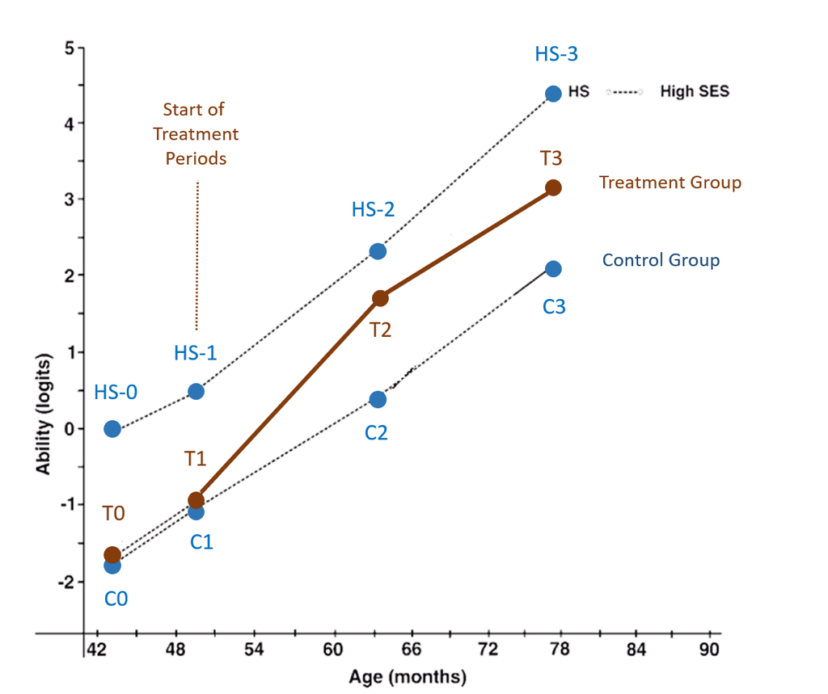

# Load Data

```r
library( dplyr )
library( scales )
library( stargazer )
library( pander )

# STARGAZER OUTPUT
#
# Use:
#
#   s.type="text"
#
# while running chunks interactively
# to see table output.
# This sets it to "html"
# when knitting the file.
s.type="html"
```

```r
URL <- "https://github.com/DS4PS/cpp-524-sum-2021/blob/main/labs/data/counterfactuals.csv?raw=true"
d <- read.csv( URL )

# set factor levels
d$group <- factor( d$group,
                   levels=c("high.ses","treatment","control"))
```

Sample sizes for each group in the panel:

```r
table( d$group,d$time ) %>% pander()
```

|  | time0 | time1 | time2 | time3 |
| --- | --- | --- | --- | --- |
| **high.ses** | 28 | 28 | 28 | 28 |
| **treatment** | 47 | 47 | 47 | 47 |
| **control** | 90 | 90 | 90 | 90 |

Group means in each time period:

```r
tapply( d$ability, list(d$group,d$time), mean ) %>%
  round(2) %>%
  pander()
```

|  | time0 | time1 | time2 | time3 |
| --- | --- | --- | --- | --- |
| **high.ses** | -0.02 | 1.44 | 3.15 | 4.61 |
| **treatment** | -1.76 | -0.72 | 2.19 | 3.34 |
| **control** | -1.76 | -0.65 | 0.64 | 2 |

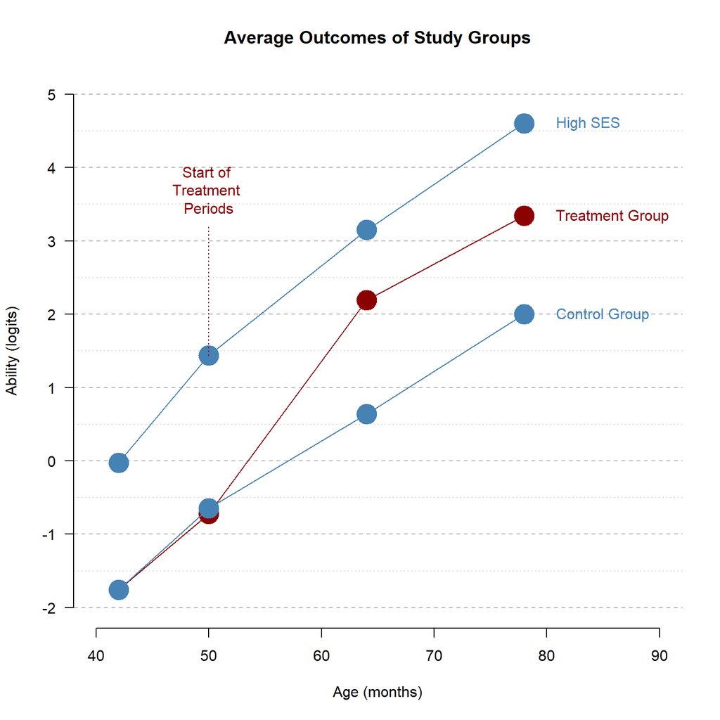

# Reflexive (Pre-Post) Estimator

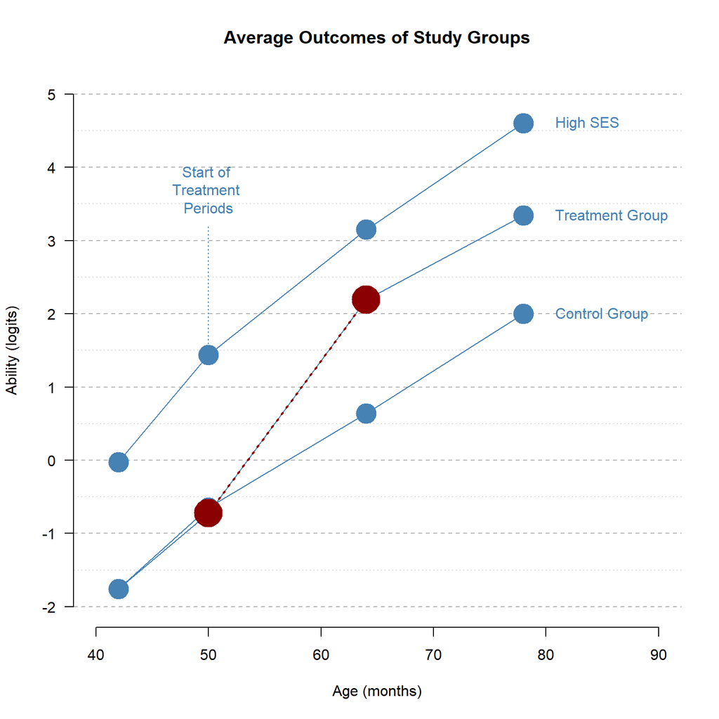

```r
dm <- filter( d,
              group %in% c("treatment") &
              time %in% c("time1","time2") )

dm$post.dummy <- ifelse( dm$time=="time2", 1, 0 )

m <- lm( ability ~ post.dummy, data=dm )

stargazer( m, type=s.type,
           omit.stat=c("f","ser","adj.rsq"),
           intercept.top=TRUE, intercept.bottom=FALSE,
           digits=2 )
```

|  | *Dependent variable:* |
| --- | --- |
|  | ability |
| Constant | -0.72*** |
|  | (0.15) |
| post.dummy | 2.91*** |
|  | (0.21) |
| Observations | 94 |
| R<sup>2</sup> | 0.67 |
| *Note:* | p<0.1; p<0.05; p<0.01 |

## Question 1

**What is the effect size in this model?**

Test for zero trend assumption: C1=C2

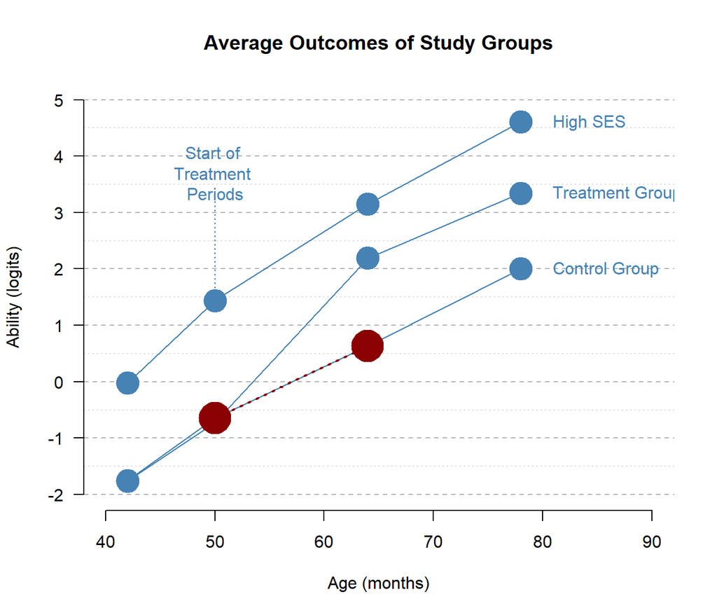

```r
dm <- filter( d,
              group %in% c("control") &
              time %in% c("time1","time2") )

dm$post.dummy <- ifelse( dm$time=="time2", 1, 0 )

m <- lm( ability ~ post.dummy, data=dm )

stargazer( m, type=s.type,
           omit.stat=c("f","ser","adj.rsq"),
           intercept.top=TRUE, intercept.bottom=FALSE,
           digits=2 )
```

|  | *Dependent variable:* |
| --- | --- |
|  | ability |
| Constant | -0.65*** |
|  | (0.12) |
| post.dummy | 1.28*** |
|  | (0.17) |
| Observations | 180 |
| R<sup>2</sup> | 0.24 |
| *Note:* | p<0.1; p<0.05; p<0.01 |

## Question 2a

**Do we observe a secular trend in student achievement gains independent of the treatment?**

## Question 2b

**What does this tell us about the appropriateness of the reflexive model?**

# Post-Test Only Estimator

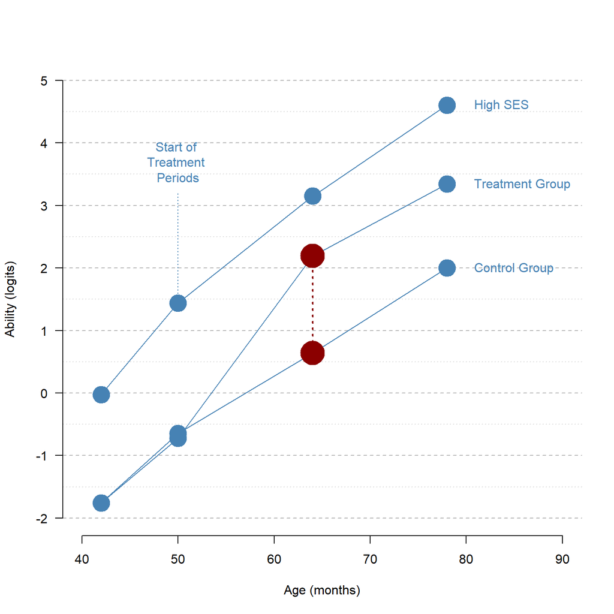

```r
dm <- filter( d,
              group %in% c("treatment","control") &
              time=="time2" )

dm$treat.dummy <- ifelse( dm$group=="treatment", 1, 0 )

m <- lm( ability ~ treat.dummy, data=dm )

stargazer( m, type=s.type,
           omit.stat=c("f","ser","adj.rsq"),
           intercept.top=TRUE, intercept.bottom=FALSE,
           digits=2 )
```

|  | *Dependent variable:* |
| --- | --- |
|  | ability |
| Constant | 0.64*** |
|  | (0.12) |
| treat.dummy | 1.55*** |
|  | (0.20) |
| Observations | 137 |
| R<sup>2</sup> | 0.31 |
| *Note:* | p<0.1; p<0.05; p<0.01 |

## Question 3a

**What is the effect size identified by the model?**

## Question 3b

**What is the identifying assumption of this model?**

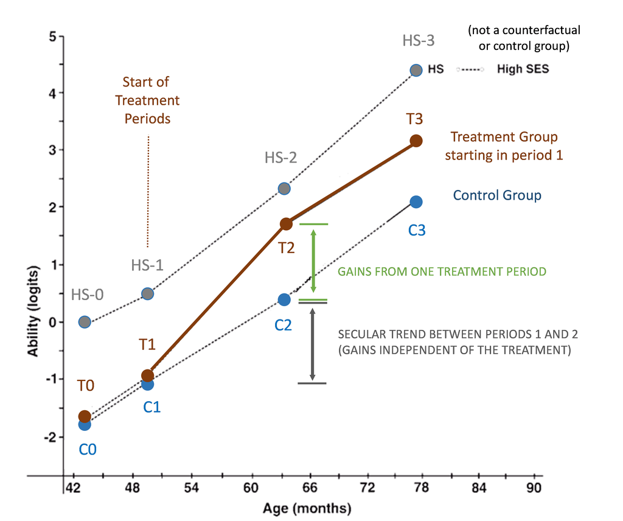

```r
dm <- filter( d,
              group %in% c("treatment","control") &
              time=="time1" )

dm$treat.dummy <- ifelse( dm$group=="treatment", 1, 0 )

m <- lm( ability ~ treat.dummy, data=dm )

stargazer( m, type=s.type,
           omit.stat=c("f","ser","adj.rsq"),
           intercept.top=TRUE, intercept.bottom=FALSE,
           digits=2 )
```

|  | *Dependent variable:* |
| --- | --- |
|  | ability |
| Constant | -0.65*** |
|  | (0.12) |
| treat.dummy | -0.07 |
|  | (0.20) |
| Observations | 137 |
| R<sup>2</sup> | 0.001 |
| *Note:* | p<0.1; p<0.05; p<0.01 |

# Diff-in-Diff Estimator

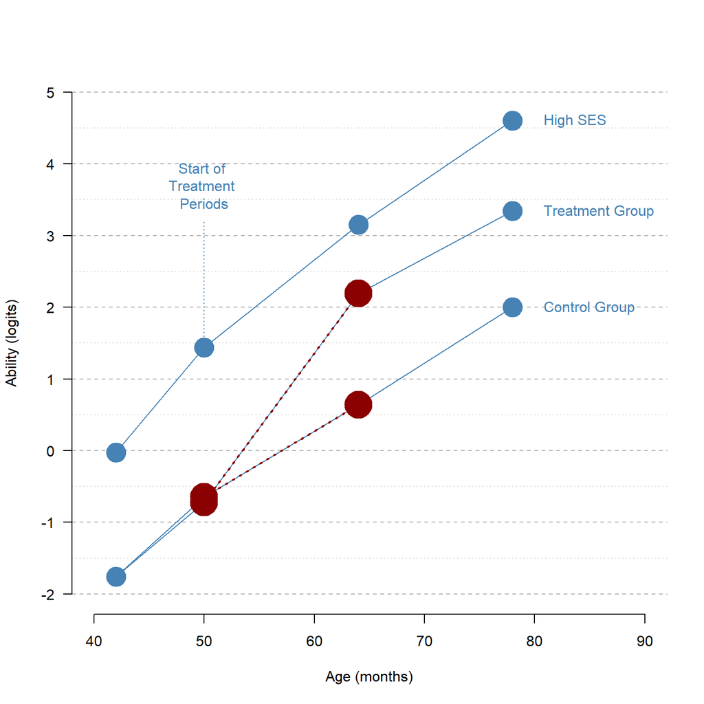

```r
dm <- filter( d, group %in% c("treatment","control") &
                time %in% c("time1","time2") )

dm$treat.dummy <- ifelse( dm$group=="treatment", 1, 0 )
dm$post.dummy  <- ifelse( dm$time=="time2", 1, 0 )

dm$treat.post.dummy <- dm$treat.dummy * dm$post.dummy

m <- lm( ability ~ treat.dummy + post.dummy + treat.post.dummy,
         data=dm)

stargazer( m, type=s.type,
           omit.stat=c("f","ser","adj.rsq"),
           intercept.top=TRUE, intercept.bottom=FALSE,
           digits=2 )
```

|  | *Dependent variable:* |
| --- | --- |
|  | ability |
| Constant | -0.65*** |
|  | (0.12) |
| treat.dummy | -0.07 |
|  | (0.20) |
| post.dummy | 1.28*** |
|  | (0.16) |
| treat.post.dummy | 1.63*** |
|  | (0.28) |
| Observations | 274 |
| R<sup>2</sup> | 0.48 |
| *Note:* | p<0.1; p<0.05; p<0.01 |

```r
b0 <- m$coefficients[1] %>% as.numeric() %>% round(2)
b1 <- m$coefficients[2] %>% as.numeric() %>% round(2)
b2 <- m$coefficients[3] %>% as.numeric() %>% round(2)
b3 <- m$coefficients[4] %>% as.numeric() %>% round(2)

b0                 # C1
```

```
## [1] -0.65
```

```r
b0 + b1            # T1
```

```
## [1] -0.72
```

```r
b0 + b2            # C2
```

```
## [1] 0.63
```

```r
b0 + b1 + b2 + b3  # T2
```

```
## [1] 2.19
```

```r
b0 + b1 + b2       # CF
```

```
## [1] 0.56
```

```r
CF <- b0 + b1 + b2
T2 <- b0 + b1 + b2 + b3
T2-CF
```

```
## [1] 1.63
```

## Question 4a

**Are the treatment and control groups equivalent prior to the intervention? How do you know?**

## Question 4b

**Do we observe secular trends (gains independent of the treatment)?**

## Question 4c

**What is the effect size (gains from the treatment)?**

## Question 4d

**What does statistical significance of b3 represent? In other words, which contrast is being tested?**

## Question 5a

**Do the reflexive and diff-in-diff models generate the same results (approximately)? Why?**

## Question 5b

**Do the post-test and diff-in-diff models generate the same results (approximately)? Why?**

# Alternative Diff-in-Diff Estimator

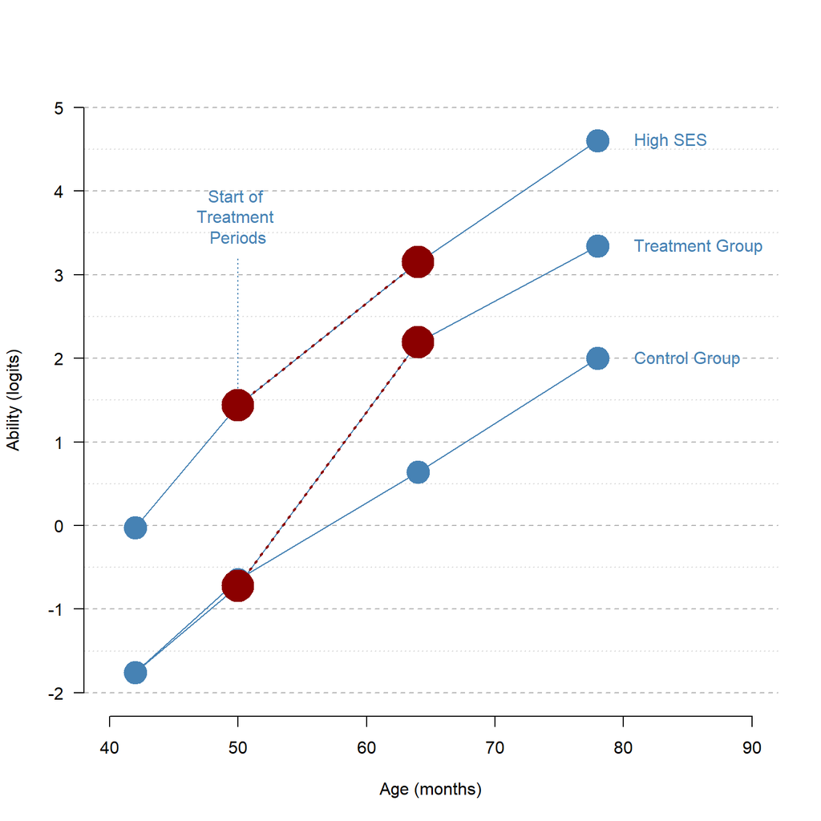

```r
dm <- filter( d, group %in% c("treatment","high.ses") &
                time %in% c("time1","time2") )

dm$treat.dummy <- ifelse( dm$group=="treatment", 1, 0 )
dm$pre.dummy   <- ifelse( dm$time=="time1", 1, 0 )
dm$post.dummy  <- ifelse( dm$time=="time2", 1, 0 )

dm$treat.post.dummy <- dm$treat.dummy * dm$post.dummy

m <- lm( ability ~ treat.dummy + post.dummy + treat.post.dummy,
         data=dm)

stargazer( m, type=s.type,
           omit.stat=c("f","ser","adj.rsq"),
           intercept.top=TRUE, intercept.bottom=FALSE,
           digits=2 )
```

|  | *Dependent variable:* |
| --- | --- |
|  | ability |
| Constant | 1.44*** |
|  | (0.19) |
| treat.dummy | -2.16*** |
|  | (0.24) |
| post.dummy | 1.71*** |
|  | (0.27) |
| treat.post.dummy | 1.20*** |
|  | (0.34) |
| Observations | 150 |
| R<sup>2</sup> | 0.68 |
| *Note:* | p<0.1; p<0.05; p<0.01 |

## Question 6a

**Are the pre-treatment differences (C1=T1?) different in this model versus the previous diff-in-diff? Why or why not?**

## Question 6b

**Does the diff-in-diff model require that study groups are equivalent prior to treatment to generate valid results? If not, what is the identification assumption of this model?**

## Question 6c

**Is the secular trend identified by this model different from the previous diff-in-diff (approximately)? Why or why not?**

## Question 6d

**The treatment effects from this model are approximately the same as the previous diff-in-diff model, even though they use very different comparison groups. Why does this model still work using the high SES group?**

# Parallel Lines Test

Does the high SES group model secular trend appropriately?

Test: are the study group trend lines parallel prior to the intervention?

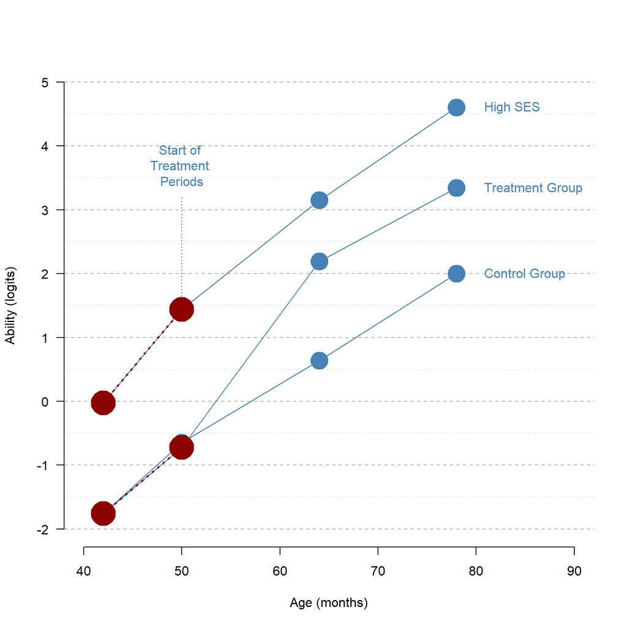

```r
dm <- filter( d, group %in% c("treatment","high.ses") &
                time %in% c("time0","time1") )

dm$treat.dummy <- ifelse( dm$group=="treatment", 1, 0 )
dm$pre.dummy   <- ifelse( dm$time=="time0", 1, 0 )
dm$post.dummy  <- ifelse( dm$time=="time1", 1, 0 )

dm$treat.post <- dm$treat.dummy * dm$post.dummy

m <- lm( ability ~ treat.dummy + post.dummy + treat.post,
         data=dm)

stargazer( m, type=s.type,
           omit.stat=c("f","ser","adj.rsq"),
           intercept.top=TRUE, intercept.bottom=FALSE,
           digits=2 )
```

|  | *Dependent variable:* |
| --- | --- |
|  | ability |
| Constant | -0.02 |
|  | (0.21) |
| treat.dummy | -1.73*** |
|  | (0.27) |
| post.dummy | 1.46*** |
|  | (0.30) |
| treat.post | -0.43 |
|  | (0.38) |
| Observations | 150 |
| R<sup>2</sup> | 0.51 |
| *Note:* | p<0.1; p<0.05; p<0.01 |

Does the control group model secular trend appropriately?

Test: are the study group trend lines parallel prior to the intervention?

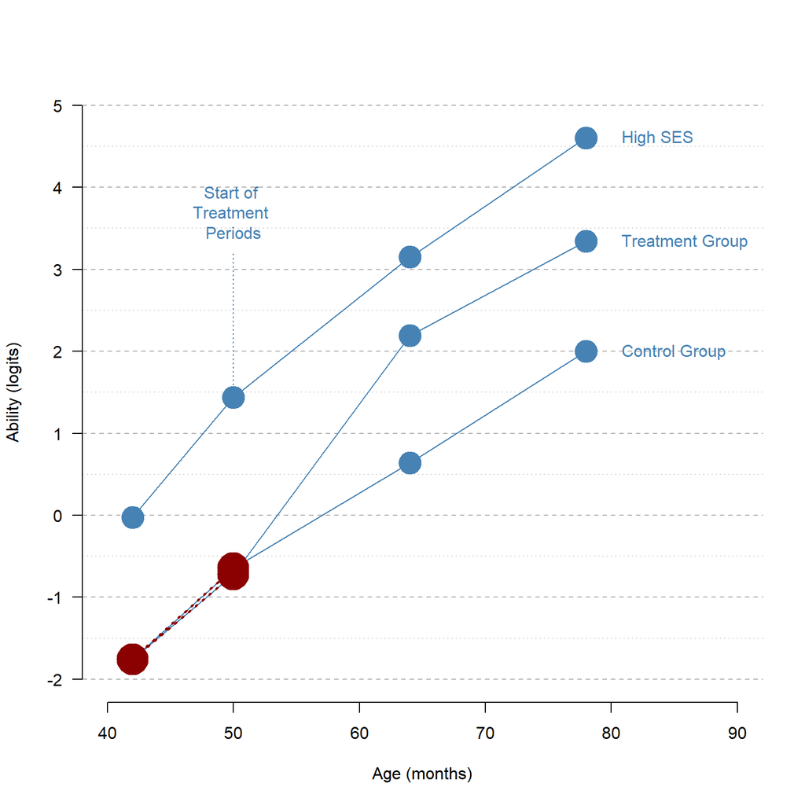

```r
dm <- filter( d, group %in% c("treatment","control") &
                time %in% c("time0","time1") )

dm$treat.dummy <- ifelse( dm$group=="treatment", 1, 0 )
dm$post.dummy  <- ifelse( dm$time=="time1", 1, 0 )

dm$treat.post <- dm$treat.dummy * dm$post.dummy

m <- lm( ability ~ treat.dummy + post.dummy + treat.post,
         data=dm)

stargazer( m, type=s.type,
           omit.stat=c("f","ser","adj.rsq"),
           intercept.top=TRUE, intercept.bottom=FALSE,
           digits=2 )
```

|  | *Dependent variable:* |
| --- | --- |
|  | ability |
| Constant | -1.76*** |
|  | (0.12) |
| treat.dummy | 0.001 |
|  | (0.21) |
| post.dummy | 1.11*** |
|  | (0.17) |
| treat.post | -0.08 |
|  | (0.29) |
| Observations | 274 |
| R<sup>2</sup> | 0.18 |
| *Note:* | p<0.1; p<0.05; p<0.01 |

## Question 7

**Which coefficient captures the parallel lines test**

**Do we want it to be significant or not?**

# Submission Instructions

When you have completed your assignment, knit your RMD file to generate your rendered HTML file.

Login to Canvas at http://canvas.asu.edu and navigate to the assignments tab in the course repository. Upload your HTML and RMD files to the appropriate lab submission link.

Remember to:

- name your files according to the convention: **Lab-##-LastName.Rmd**.
- show your solution, include your code.
- format your regression tables using stargazer
- bold your answers.
- do NOT print excessive output (like a full data set).
- follow appropriate style guidelines (spaces between arguments, etc.).

Labs designed by Jesse Lecy  
Content licensed under Creative Commons: [(CC BY-NC-SA 4.0)](https://creativecommons.org/licenses/by-nc-sa/4.0/)  
Source code is available on [GitHub](https://github.com/DS4PS/cpp-524-sum-2020/tree/master/labs)  
CPP 524 [Foundations of Prog Eval II](https://ds4ps.org/cpp-524-sum-2020/)  
Part of the [MS in Evaluation and Analytics](http://ds4ps.org/ms-prog-eval-data-analytics/)  
@ [Arizona State University](https://asuonline.asu.edu/online-degree-programs/graduate/program-evaluation-and-data-analytics-ms/)  
Copyright © 2020

Solutions may **NOT** be posted online  
without violating ASU policies and copyright laws.